# Template

Austin Palmer

2023-04-19

###### Goals

Expand our generalized hierarchical regression model toolkit by combining:

- Hierarchical regression techniques with
- Poisson and Negative Binomial Regression Models for count response variables $Y$ and logistic regression models for binary categorical response variables $Y$

```r
# Load packages
library(bayesrules)
library(tidyverse)
```

```r
library(bayesplot)
library(rstanarm)
library(tidybayes)
library(broom.mixed)
library(janitor)
```

# Random Intercepts Logistic Regression Model

What’s the probability that a mountain climber makes it to the top? What factors might contribute to a higher success rate? Beyond a *vague* sense that the typical climber has a 50/50 chance at success, we’ll balance our weakly informative prior understanding of these questions with the `climbers_sub` data.

```r
data(climbers_sub)
climbers <- climbers_sub %>%
  select(expedition_id, member_id, success, year, season, age, expedition_role, oxygen_used)
```

This dataset includes the outcomes for 2076 climbers, dating back to 1978. Among them, only 38.87% successfully summited their peak:

```r
nrow(climbers)
```

```
## [1] 2076
```

```r
climbers %>%
  tabyl(success)
```

```
##  success    n   percent
##    FALSE 1269 0.6112717
##     TRUE  807 0.3887283
```

`expedition_id` is our grouping variable, the `climbers` data spans 200 different expeditions with different numbers of climbers per expedition:

```r
# Size per expedition
climbers_per_expedition <- climbers %>%
  group_by(expedition_id) %>%
  summarize(count = n())
climbers_per_expedition
```

```
## # A tibble: 200 × 2
##    expedition_id count
##    <chr>         <int>
##  1 AMAD03107         5
##  2 AMAD03327         6
##  3 AMAD05338        12
##  4 AMAD06110         5
##  5 AMAD06334        11
##  6 AMAD07101         8
##  7 AMAD07310        17
##  8 AMAD07337         7
##  9 AMAD07340        10
## 10 AMAD09331         6
## # … with 190 more rows
```

```r
# Number of expeditions
nrow(climbers_per_expedition)
```

```
## [1] 200
```

It would be a **mistake** to ignore this grouping structure and assume that our individual climber outcomes are independent. Since each expedition works as a *team*, the success or failure of one climber in that expedition depends in part on the success or failure of another. Further, all expedition members start out with the same destination, with the same leaders, and under the same weather conditions, and thus are subject to the same external factors of success. Beyond correctness, accounting for the grouping structure also illuminates the degree to which these factors introduce variability in the success rates *between* expeditions.

To this end, notice that more than 75 of our 200 expeditions had a 0% success rate - i.e., *no* climbers in these groups made it to the peak. In contrast, nearly 20 expeditions had a 100% success rate. In between these extremes, there’s quite a bit of variability:

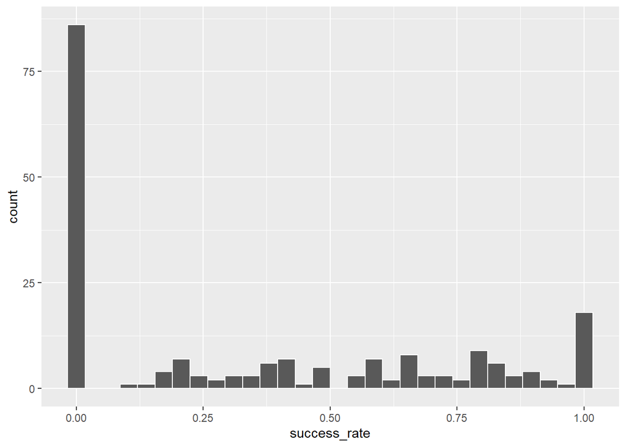

```r
# Calculate the success rate for each exhibition
expedition_success <- climbers %>%
  group_by(expedition_id) %>%
  summarize(success_rate = mean(success))

# Plot the success rates across exhibitions
ggplot(expedition_success, aes(x = success_rate)) +
  geom_histogram(color = "white")
```

## Model Building

Reflecting the grouped nature of our data, let $Y_{ij}$ denote whether climber $i$ in expedition $j$ successfully summits their peak:

We’ll consider two predictors:

1. Climber age
2. Whether they received supplemental oxygen

$X_{ij1} =$ climber $i$ age in expedition $j$

$X_{ij2} =$ Oxygen dummy variable

Calculating the proportion of success at each age and oxygen use combination, we can get a sense of how these factors are related to climber success.

```r
data_by_age_oxygen <- climbers %>%
  group_by(age, oxygen_used) %>%
  summarize(success_rate = mean(success))
```

[output not shown]

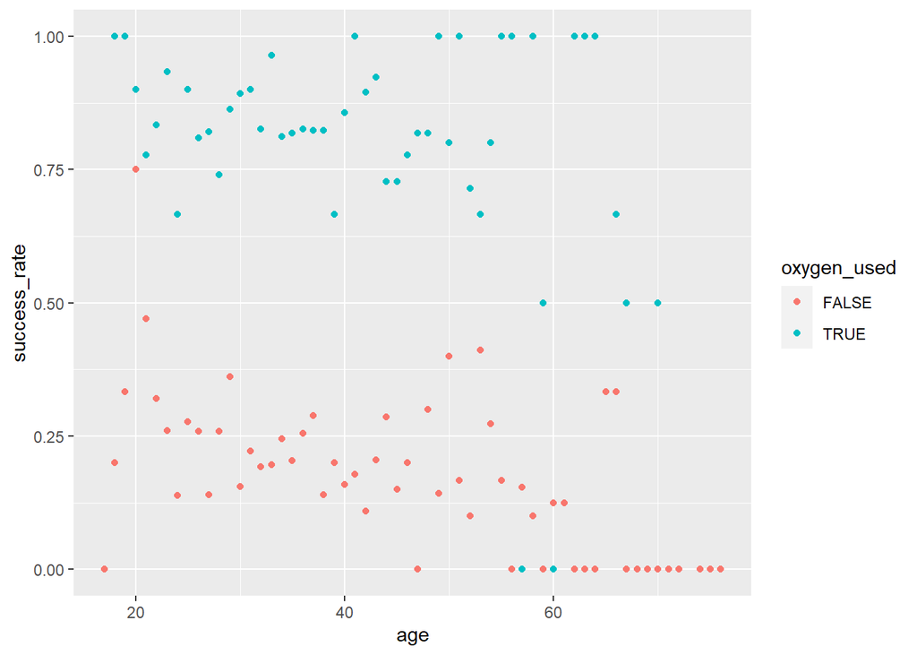

```r
# Plot this relationship
ggplot(data_by_age_oxygen, aes(x = age, y = success_rate,
                               color = oxygen_used)) +
  geom_point()
```

In summary, it appears the climber success decreases with age and dramatically increases with the use of oxygen.

In building a Bayesian model of this relationship, first recognize that the Bernoulli model is reasonable for our binary response variable $Y_{ij}$. Letting $\pi_{ij}$ be the probability that climber $i$ in expedition $j$ successfully summits their peak, i.e., that $Y_{ij}$ = 1.

$$Y_{ij}|\pi_{ij} \sim
Bern(\pi_{ij})$$

Before we used this **complete pooling** approach to expand the simple model into a **logistic regression model**:

$$Y_{ij}|\beta_0,\beta_1,\beta_2 \sim
Bern(\pi_{ij}) \text{ with } log(\frac{\pi_{ij}}{1 - \pi_{ij}}) =
\beta_0 + \beta_1X_{ij1} + \beta_2X_{ij2}$$

$$\beta_{0c} \sim
N(m_0,s_0^2)$$

$$\beta_1 \sim N(m_1,s_1^2)$$

$$\beta_2 \sim N(m_2,s_2^2)$$

This is a good start, **but doesn’t account for the grouping structure**. We combine

$$Y_{ij}|\beta_{0j},\beta_1,\beta_2 \sim
Bern(\pi_{ij}) \text{ with } log({\frac{\pi_{ij}}{1 - \pi_{ij}}}) =
\beta_{0j} + \beta_1X_{ij1} + \beta_2X_{ij2} \text{ (model within
expedition j)}$$

$$\beta_{0j}|\beta_0,\sigma_0 \sim
N(\beta_0, \sigma_0^2) \text{ (variability between
expeditions)}$$

$$\text{Global Priors:}$$

$$\beta_{0c} \sim N(0,2.5^2)$$

$$\beta_1 \sim N(0, 0.24^2)$$

$$\sigma_0 \sim Exp(1)$$

*Eventually* we can reframe this **random intercepts logistic regression model** by expression expedition-specific intercepts as *tweaks* to the global intercept:

$$log({\frac{\pi_{ij}}{1 - \pi_{ij}}}) =
(\beta_{0} + b_{0j}) + \beta_1X_{ij1} + \beta_2X_{ij2}$$

- The **expedition-specific** intercepts $\beta_{0j}$ describe the underlying success rates, as measured by the log(odds of success), for each expedition $j$. These acknowledge that some expeditions are inherently more successful that others.
- The expedition-specific intercepts $\beta_{0j}$ are assumed to be Normal distributed around some global intercept $\beta_0$ with stdev $\sigma_0$ captures the **between-group variability** in success rates from expedition to expedition
- $\beta_1$ describes the **global** relationship between success and age when controlling for oxygen use. Similarly, $\beta_2$ describes the global relationship between success and oxygen use when controlling for age.

Putting this all together, our random intercepts logistic regression model makes the simplifying but reasonable assumption that expeditions might have *unique* intercepts $\beta_{0j}$, but share common regression parameters $\beta_1$ and $\beta_2$. **In plain language**, thought the *underlying success rates* might differ from expedition to expedition, being younger or using oxygen aren’t more beneficial in one expedition than in another.

## Model Simulation

`family = binomial` specifies that ours is a *logistic* regression

`(1 | expedition_id)` incorporates our grouping structure

```r
climb_model <- stan_glmer(
  success ~ age + oxygen_used + (1 | expedition_id),
  data = climbers, family = binomial,
  prior_intercept = normal(0, 2.5, autoscale = TRUE),
  prior = normal(0, 2.5, autoscale = TRUE),
  prior_covariance = decov(reg = 1, conc = 1, shape = 1, scale = 1),
  chains = 4, iter = 5000*2, seed = 84735
)
```

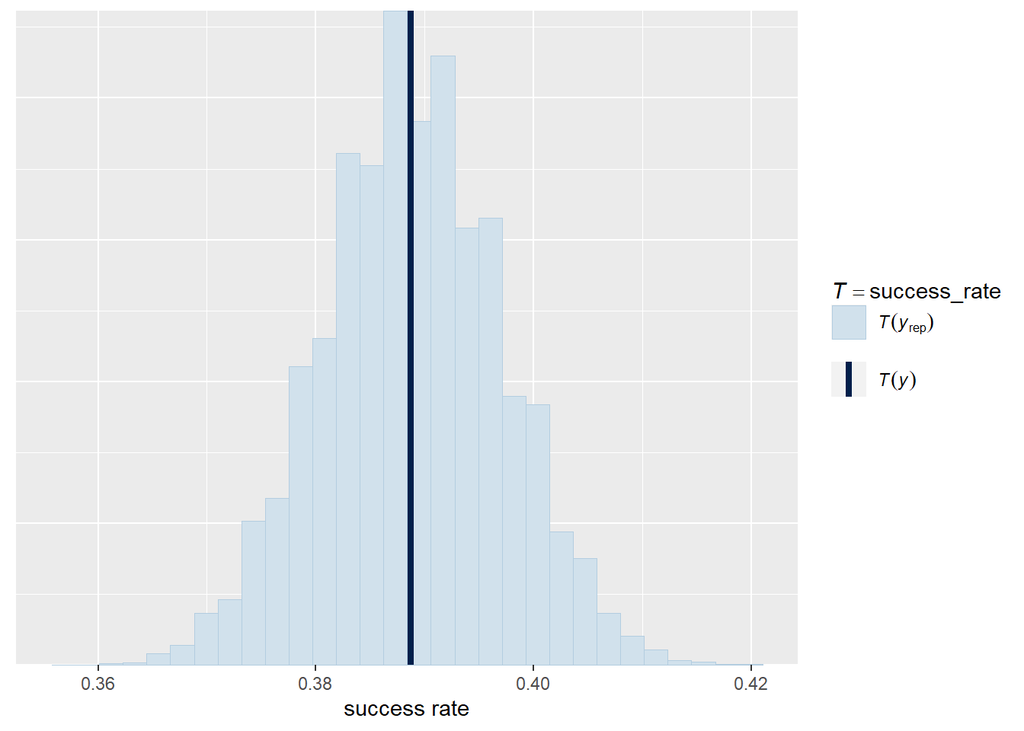

```r
# Define success rate function
success_rate <- function(x){mean(x == 1)}

# Posterior predictive check
pp_check(climb_model, nreps = 100,
         plotfun = "stat", stat = "success_rate") +
  xlab("success rate")
```

A posterior predictive check indicators that our model is on the right track. For each of 100 posterior simulated datasets, we record the proportion of climbers that were successful using the `success_rate()` function. These success rates range from roughly 36% to 41%, in a tight window around the actual observed 38.9% success rate in the `climbers` data.

## Posterior Analysis

Lets focus on the global, we’re not really interested in any *particular* expedition beyond being comforted we’re correctly accounting for the grouping structure. Below are the posterior summaries for our global regression parameters:

```r
tidy(climb_model, effects = "fixed", conf.int = TRUE, conf.level = 0.80)
```

```
## # A tibble: 3 × 5
##   term            estimate std.error conf.low conf.high
##   <chr>              <dbl>     <dbl>    <dbl>     <dbl>
## 1 (Intercept)      -1.41     0.475    -2.04     -0.818
## 2 age              -0.0475   0.00908  -0.0593   -0.0360
## 3 oxygen_usedTRUE   5.79     0.482     5.19      6.45
```

Observations:

1. `age` 80% Posterior credible interval is comfortably below 0. We have significant evidence that, when controlling for whether or not a climber uses oxygen, the likelihood of success decreases with age. More specifically, there’s an 80% chance that the *odds* of successfully summiting drop between 3.5% and 5.8% for every extra year of age: ($e^{-0.0594},e^{-0.0358}$) = (0.942, 0.965).
2. `oxygen_usedTRUE` coefficient $\beta_2$ provides *significant* posterior evidence that, when controlling for age, the use of oxygen dramatically increases a climbers likelihood of summiting the peak. 80% chance that the use of oxygen corresponds to anywhere between an 182-fold increase to a 617-fold increase in the odds of success: ($e^{5.2},e^{6.43}$) = (182,617).

Combining our observations on $\beta_1$ and $\beta_2$, the posterior median model of the relationship between climbers’ log(odds of success) and their age($X_1$) and oxygen use ($X_2$) is:

$$log(\frac{\pi}{1-\pi}) = -1.42 -
0.0474X_1 + 5.79X_2$$

Or, on the probability of success scale:

$$\pi = \frac{exp(-1.42 - 0.0474X_1 +
5.79X_2)}{1 + exp(-1.42 - 0.0474X_1 + 5.79X_2)}$$

This represents the *center* among a range of posterior plausible relationship between success, age, and oxygen use. To get a sense for this range, we plot 100 posterior plausible alternative models below.

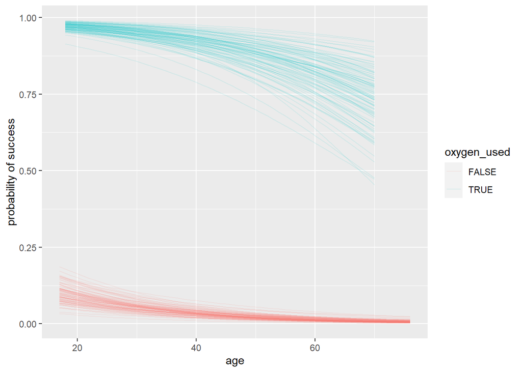

```r
climbers %>%
  add_fitted_draws(climb_model, n = 100, re_formula = NA) %>%
  ggplot(aes(x = age, y = success, color = oxygen_used)) +
    geom_line(aes(y = .value, group = paste(oxygen_used, .draw)),
              alpha = 0.1) +
    labs(y = "probability of success")
```

Both with oxygen and without, the probability of success decreases with age. Further, at any give age, the probability of success is *drastically* high when climbers use oxygen. However, our posterior certainty in these trends varies quite a bit by age. We have *much* less certainty about the success rate for older climbers on oxygen than for younger climbers on oxygen, or whom the success rate is uniformly high. Similarly, but less drastically, we have less certainty about the success rate for younger climbers who don’t use oxygen than for older climbers who don’t use oxygen, fo whom the success rate is uniformly low.